# main

### Discrete

#### Barplot

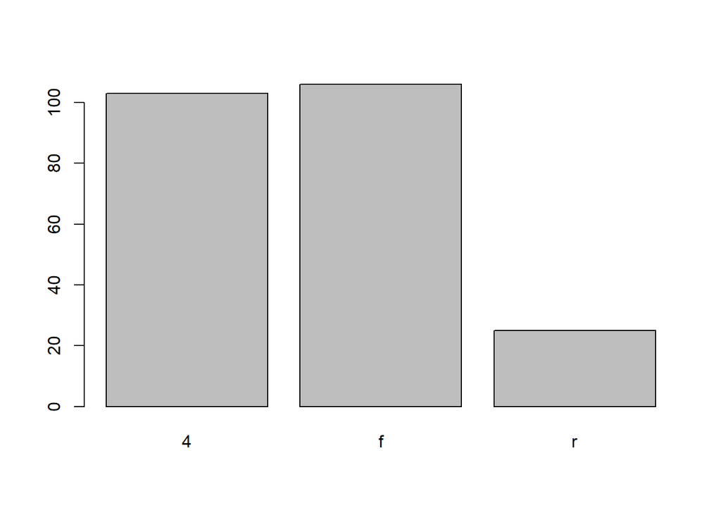

```r
tabdat <- table(mpg$drv)
barplot(tabdat)
```

#### Different type of bar plot

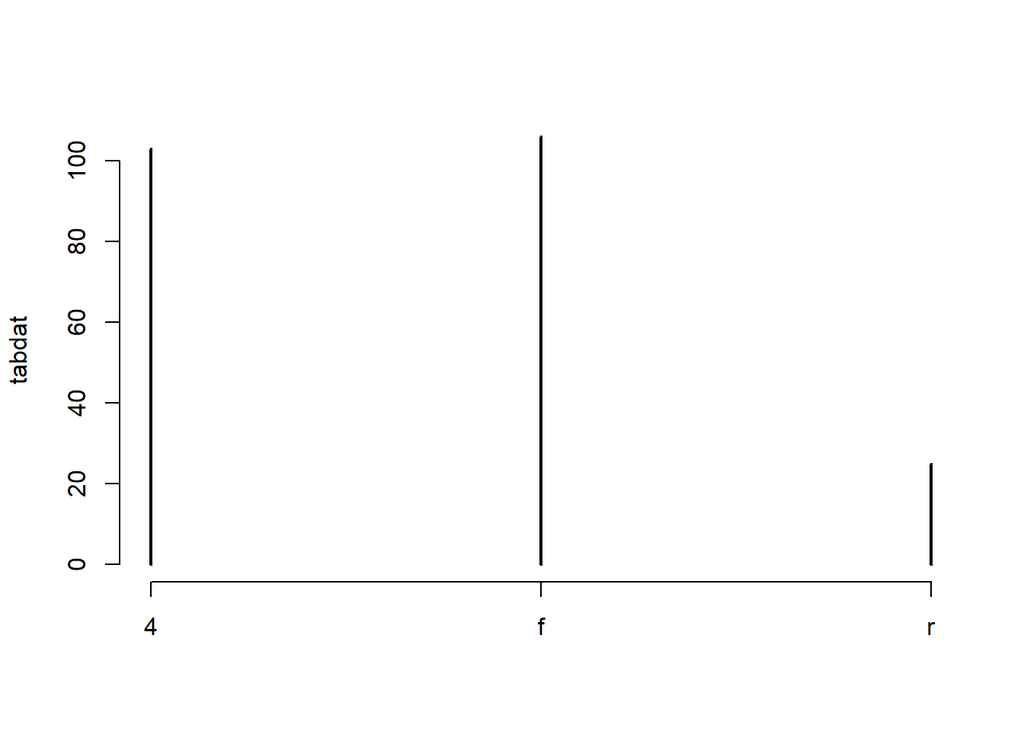

```r
plot(tabdat)
```

### Two Variables

#### Continuous X, Continuous Y

##### Scatterplot

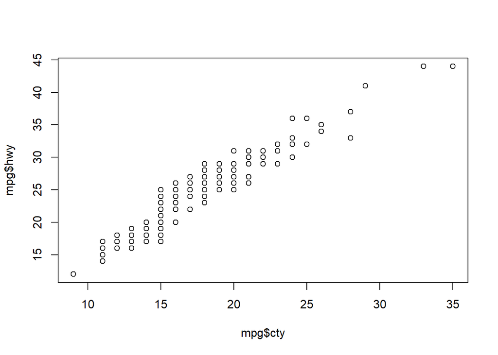

```r
plot(mpg$cty, mpg$hwy)
```

Jitter points to account for overlaying points.

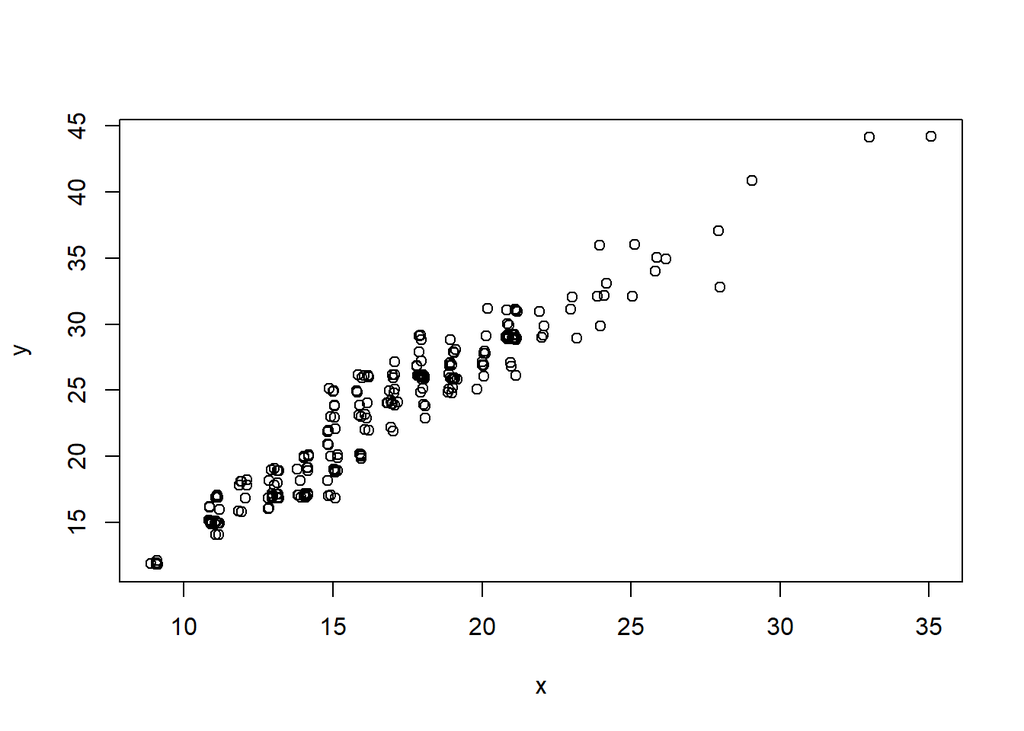

```r
x <- jitter(mpg$cty)
y <- jitter(mpg$hwy)
plot(x, y)
```

##### Add a rug plot

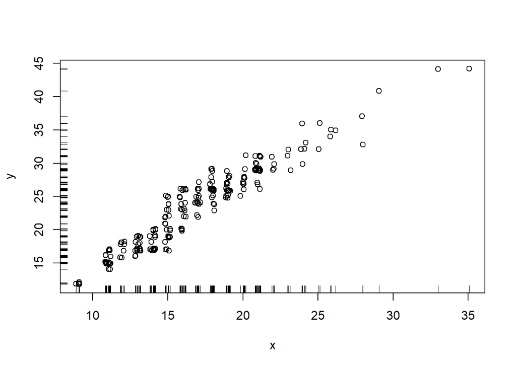

```r
plot(x, y)
rug(x, side = 1)
rug(y, side = 2)
```

##### Add a Loess Smoother

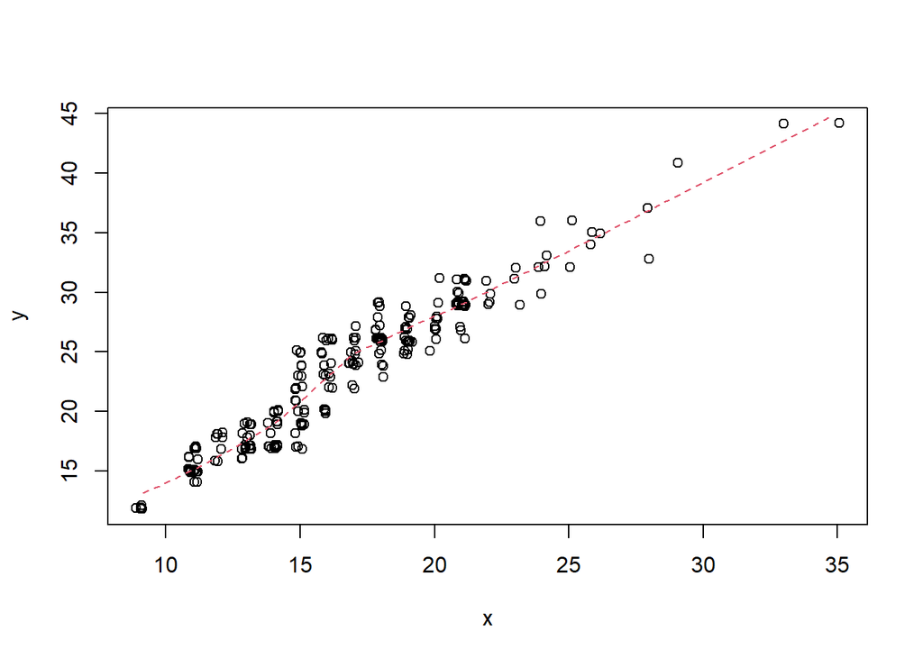

```r
loess_fit <- loess(hwy ~ cty, data = mpg)
xnew <- seq(min(x), max(x), length = 100)
ynew <- predict(object = loess_fit, newdata = data.frame(cty = xnew))
plot(x, y)
lines(xnew, ynew, col = 2, lty = 2)
```

##### Loess smoother with upper and lower 95% confidence bands

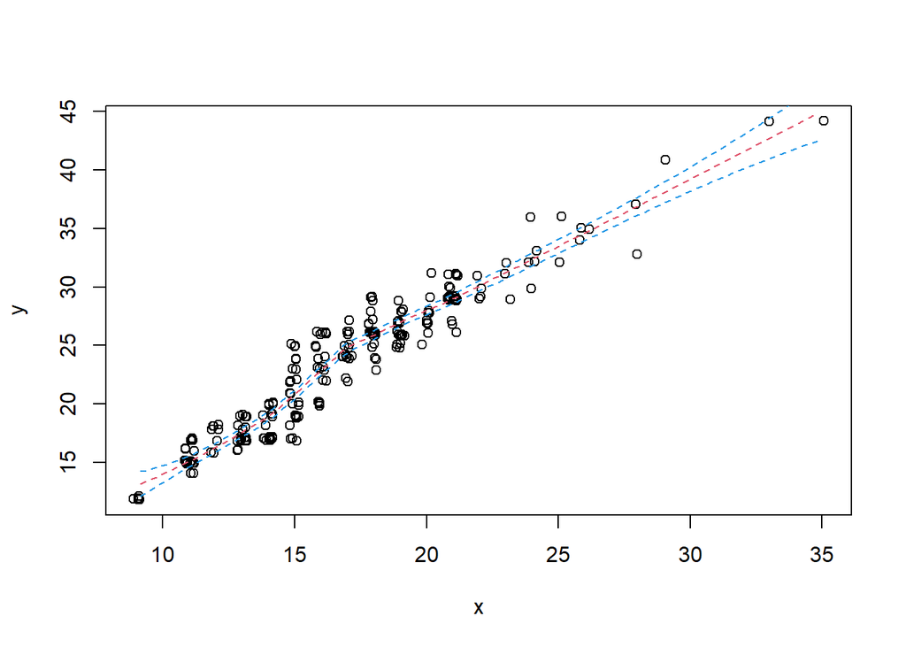

```r
loess_fit <- loess(hwy ~ cty, data = mpg)
xnew <- seq(min(x), max(x), length = 100)
pfit <- predict(object = loess_fit, newdata = data.frame(cty = xnew), se = TRUE)
ynew <- pfit$fit
upper_bound <- pfit$fit + qnorm(0.975) * pfit$se.fit
lower_bound <- pfit$fit - qnorm(0.975) * pfit$se.fit
plot(x, y)
lines(xnew, ynew, col = 2, lty = 2)
lines(xnew, upper_bound, col = 4, lty = 2)
lines(xnew, lower_bound, col = 4, lty = 2)
```

##### Loess smoother with upper and lower 95% confidence bands and that fancy shading from ggplot2.

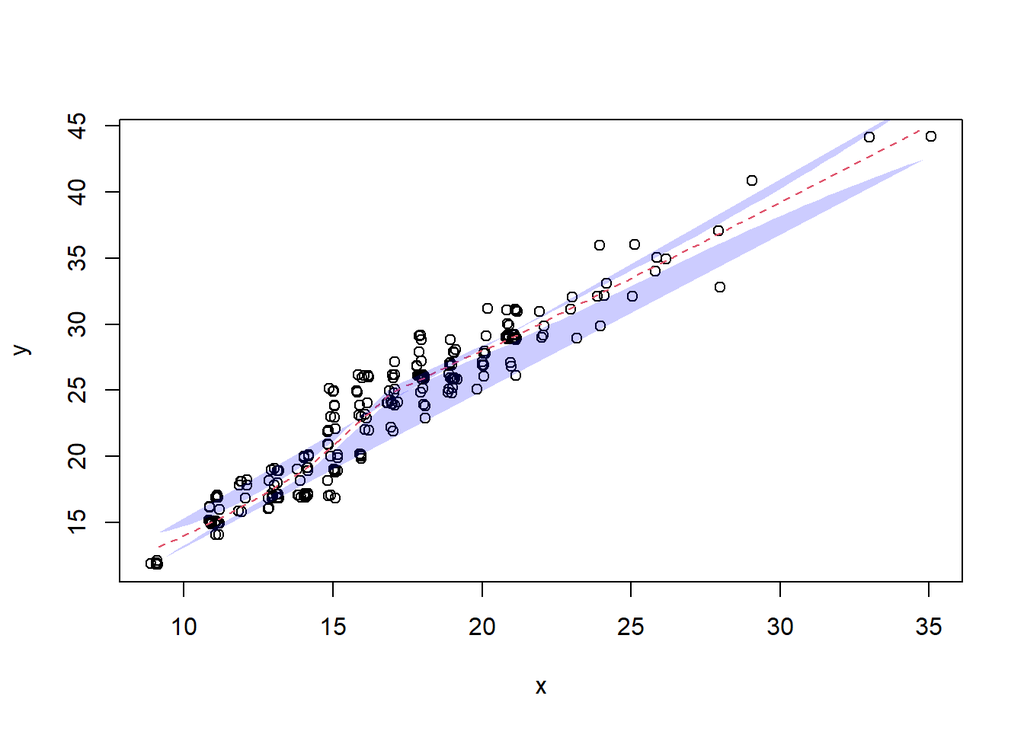

```r
loess_fit <- loess(hwy ~ cty, data = mpg)
xnew <- seq(min(x), max(x), length = 100)
pfit <- predict(object = loess_fit, newdata = data.frame(cty = xnew), se = TRUE)
ynew <- pfit$fit
upper_bound <- pfit$fit + qnorm(0.975) * pfit$se.fit
lower_bound <- pfit$fit - qnorm(0.975) * pfit$se.fit
xshade <- c(xnew, xnew[length(xnew):1])
yshade <- c(upper_bound, lower_bound[length(lower_bound):1])
plot(x, y)
lines(xnew, ynew, col = 2, lty = 2)
polygon(xshade, yshade, col = "#0000FF33", border = FALSE)
```

##### Add text to a plot

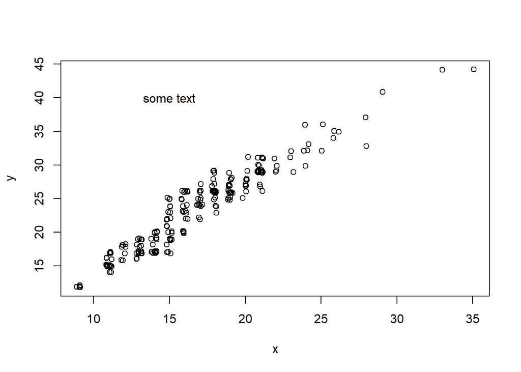

```r
plot(x, y)
text(15, 40, "some text")
```

### Discrete X, Continuous Y

#### Boxplot

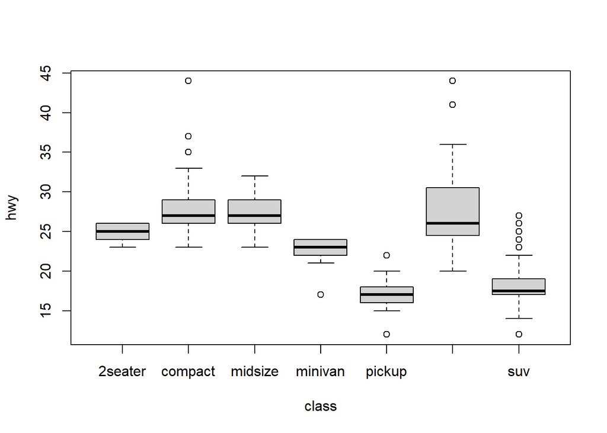

```r
boxplot(hwy ~ class, data = mpg)
```

### Discrete X, Discrete Y

#### Mosaic Plot

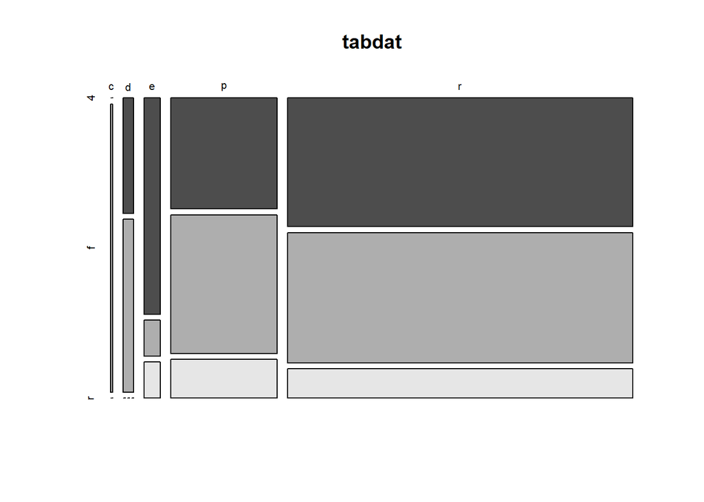

```r
tabdat <- table(mpg$fl, mpg$drv)
mosaicplot(tabdat, color = TRUE)
```

#### Continuous Function

##### Line plot

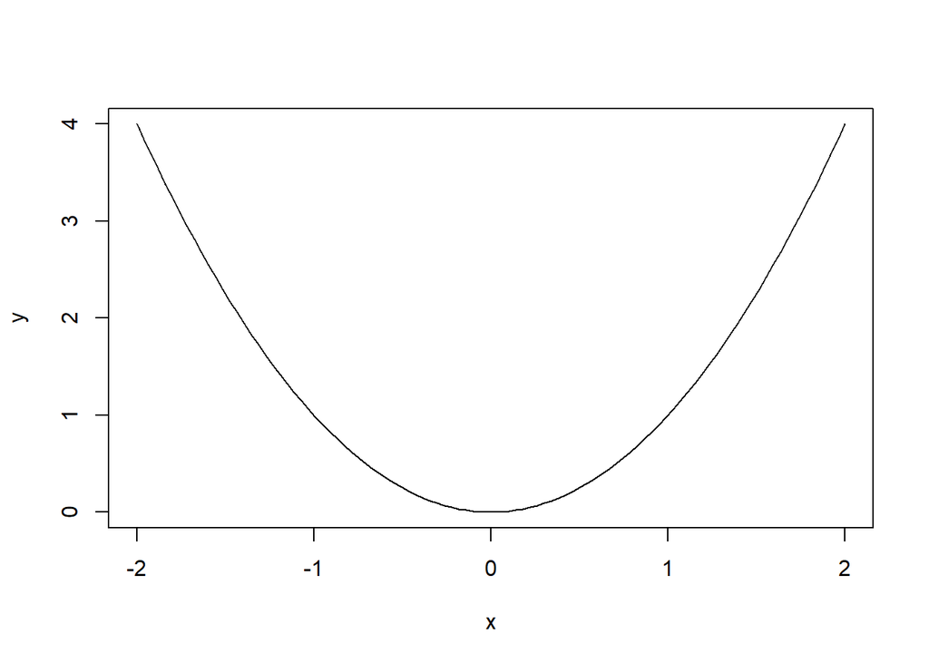

```r
f <- function(x) {
  return(x ^ 2)
}

x <- seq(-2, 2, length = 100)
y <- f(x)
plot(x, y, type = "l")
```

### Color Coding and Legends

##### Color code a scatterplot by a categorical variable and add a legend.

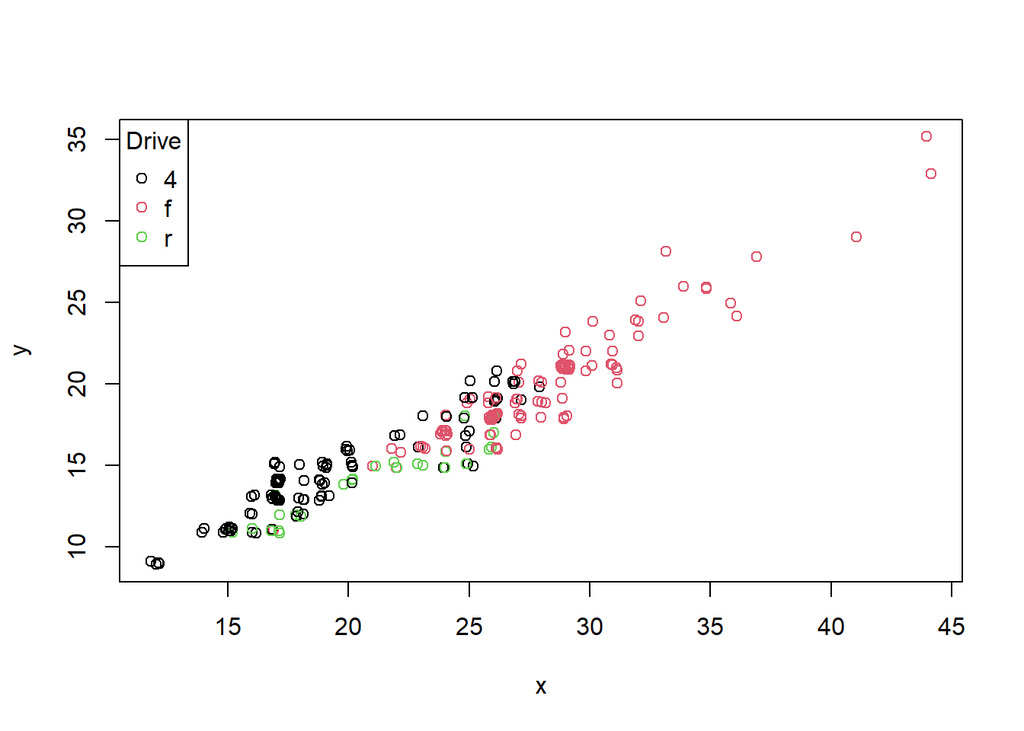

```r
x <- jitter(mpg$hwy)
y <- jitter(mpg$cty)
z <- factor(mpg$drv)
plot(x, y, col = z)
legend("topleft", legend = levels(z), col = 1:nlevels(z), pch = 1, title = "Drive")
```

##### Faceting

par sets the graphics options, where mfrow is the parameter controling the facets.

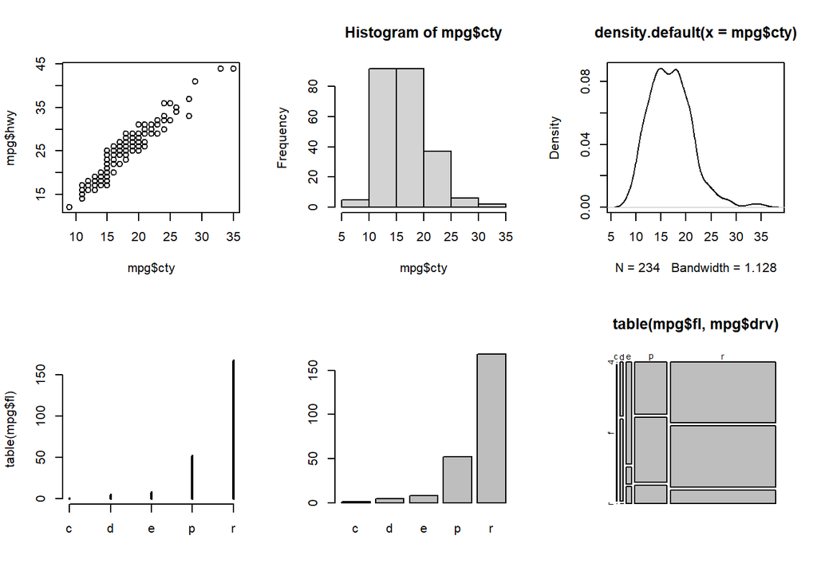

```r
old_options <- par(mfrow = c(2, 3))
plot(mpg$cty, mpg$hwy)
hist(mpg$cty)
plot(density(mpg$cty))
plot(table(mpg$fl))
barplot(table(mpg$fl))
plot(table(mpg$fl, mpg$drv))
```

```r
par(old_options)
```

The first line sets the new options and saves the old options in the list old_options. The last line reinstates the old options.